# Analysis of Home Mortgage Disclosure Act Data

Alyssa Cristobal

# Within Washington, DC, do credit unions provide better mortgage opportunities for local communities than banks?

To explain the importance of this research question, I will follow up with another question: Do you know what a credit union is?

Before this year I had no clue what a credit union was and what the whole “credit union movement” was either.

Credit unions are financial institutions, similar to banks, but they are nonprofit entities that the members own. They aim to solely exist for the benefit of their members.

The purpose of this research question is to put a value to how much credit union actually benefit their local communities and their members. Using the Home Mortgage Disclosure Act Data I can compare banks to credit unions to see if credit unions provide better mortgage opportunities than banks. Of course, this is a very specific topic but it is the beginning to actually putting a value to credit unions and showing whether or not they actually are more beneficial than banks.

By this end of this report we definitely won’t settle whether or not credit unions are better than banks. However, we will be able to contribute to that debate and see whether credit unions are more inclined than banks to originate mortgage loans to their members.

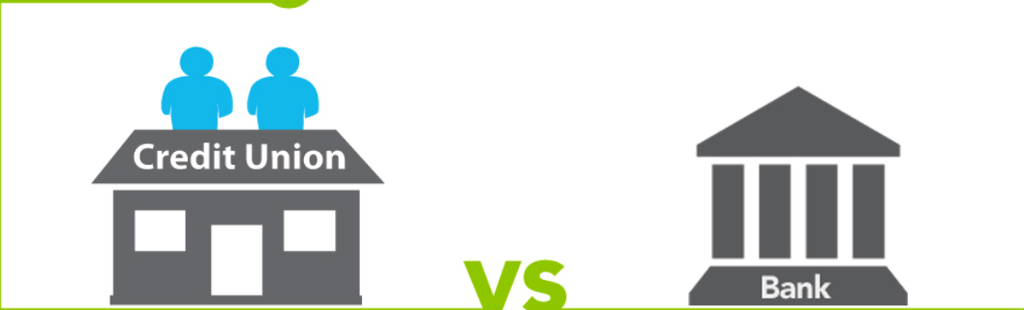

Source: https://www.usccu.org/

# Data Sources

Link to my data source:

https://www.consumerfinance.gov/data-research/hmda/historic-data/?geo=nationwide&records=all-records&field_descriptions=labels

The data I am using comes from the Consumer Financial Protection Bureau (CFPB). Their data is technically processed by the CFPB and formatted in csv files and can be uploaded with filters of: “Mortgages for first lien, owner-occupied, 1-4 family homes”, “All originated mortgages”, and “All records.” However, they do not offer completely raw data of these reports in order to protect applicant and borrower privacy. I can also filter the data per state rather than nationwide. The Consumer Financial Protection Bureau has data collected under the House Mortgage Disclosure act from 2007-2017. The data is free and public, and should be highly reliable coming from the Consumer Financial Protection Bureau. The Federal Financial Institutions Examination Council (FFIEC) mandates certain institutions report their data each year, as of 2018, only credit unions with over $45 million in assets were mandated to report. Also, as of the information provided, the only empty slots they intentionally include in their data tables are when thee are blank spots because there were no edit failures in their loans.

When attempting to download all of the data, I realized the nationwide reports were way too large to load so I decided to download the data from DC spanning over the 11 years. HMDA data helps analysts look at market activity by lender, geography, race, gender, and household income.

For more information on the Home Mortgage Disclosure Act:

https://www.ffiec.gov/hmda/reporter.htm

HMDA Loan Application Register Format: https://files.consumerfinance.gov/hmda-historic-data-dictionaries/lar_record_format.pdf

HMDA Loan Application Register Code Sheet: https://files.consumerfinance.gov/hmda-historic-data-dictionaries/lar_record_codes.pdf

# Relevant Data

The raw data given had an immense amount of variables, and for the purpose of what I am trying to prove, I cut it down by a lot. To start, I filtered my data to only look at the agencies: Federal Deposit Insurance Corporation and the National Credit Union Administration. I do this because I only care to compare banks and credit unions and these are the two agencies that the types are held within. The variables I created across the numerous data sets I made were mean applicant income (of the loans originated), median applicant income (of the loans originated), total loans originated, and percent of loans originated. Originally, I was only interested in looking at the loans originated by the two agencies so I filtered out for that, and then continued to look at the entire applicant pool between the two institutions as I realized there were discrepancies between the two. To be more specific, banks in total reach out to more members/receive more applications than credit unions because they are more commercialized so it wasn’t fair to look at the total loans originated between the two.

In the results you will definitely see a progression of my data as when one graph points against my hypothesis that credit unions are more beneficial, I try to normalize the data and create different metrics to further explore.